# R Project

Lauren

5/21/2019

## R Final project

- Look at the relationship between playoff overtime goals and play off win percentage for NHL teams

##Library list

##Data import/set up

```r
nhl_rec <- read_xls("nhl_r.xls", sheet = 1)
nhl_rec_team <- as_tibble(nhl_rec)
nhl_ot <- read_xls("nhl_r.xls", sheet = 2)
nhl_ot_team <- count(nhl_ot, "Team")
names(nhl_rec)[1] = 'TeamID'
nhl_data1 <- nhl_rec %>% left_join(nhl_ot_team, by = c('TeamID'='Team'))
nhl_data1[is.na(nhl_data1)] <- 0
head(nhl_data1)
```

```
## # A tibble: 6 x 6
##   TeamID Team                    W     L  Pct.  freq
##   <chr>  <chr>               <dbl> <dbl> <dbl> <dbl>
## 1 ANA    Anaheim Ducks          16    13 0.552     0
## 2 ARI    Arizona Coyotes         4    19 0.174     0
## 3 BOS    Boston Bruins          60    65 0.48     38
## 4 BUF    Buffalo Sabres         21    29 0.42     21
## 5 CGY    Calgary Flames         16    28 0.364    11
## 6 CGS    Carolina Hurricanes    12    12 0.5       0
```

```r
nhl_data2 <- nhl_rec %>% left_join(nhl_ot, by = c("TeamID" = "Team"))
  nhl_data2$Date <- as.Date(nhl_data2$Date, format = "%Y-%m-%d")
head(nhl_data2)
```

```
## # A tibble: 6 x 15
##   TeamID Team      W     L  Pct. Date       Location Rd       Gm ..5
##   <chr>  <chr> <dbl> <dbl> <dbl> <date>     <chr>    <chr> <dbl> <chr>
## 1 ANA    Anah…    16    13 0.552 NA         <NA>     <NA>     NA <NA>
## 2 ARI    Ariz…     4    19 0.174 NA         <NA>     <NA>     NA <NA>
## 3 BOS    Bost…    60    65 0.48  1930-03-20 MTM      SF        1 <NA>
## 4 BOS    Bost…    60    65 0.48  1931-03-24 BOS      SF        1 <NA>
## 5 BOS    Bost…    60    65 0.48  1933-03-25 BOS      SF        1 <NA>
## 6 BOS    Bost…    60    65 0.48  1933-03-30 TOR      SF        3 <NA>
## # … with 5 more variables: Name <chr>, `Final Score` <chr>, Opp. <chr>,
## #   OTs <dbl>, `OT Time` <dttm>
```

##Rough win% and OT goal freq plot - Graph of total playoff OT goals and overall win percentage - this graph fails to take into account that some teams have been in the league for far longer than others

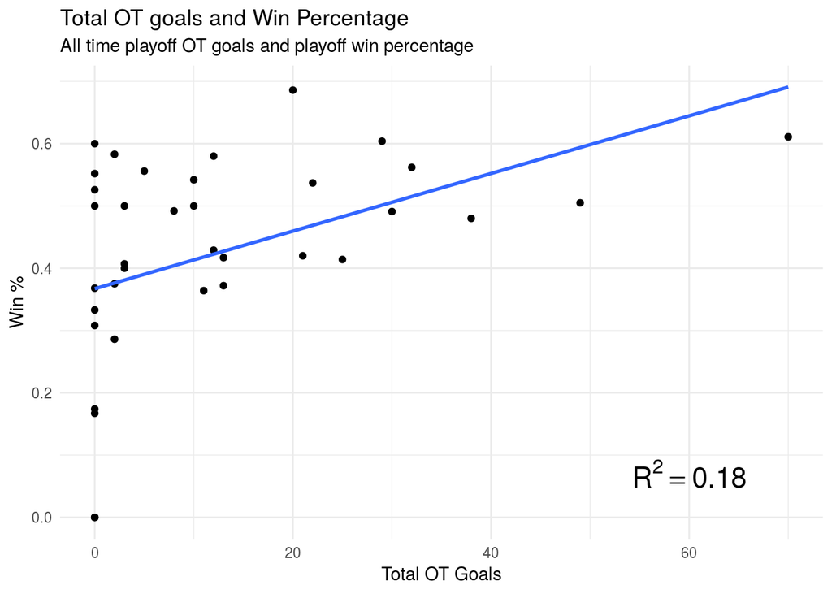

```r
mod1 <- lm(freq ~ Pct., data = nhl_data1)
r2 <- broom::glance(mod1) %>% pull(r.squared) %>%
  round(., 2)

plt1 <- ggplot(data = nhl_data1, aes(x = freq, y = Pct.)) + # Check your variable names
  geom_point() +
  geom_smooth(method = lm, se = FALSE) +
  labs( title = "Total OT goals and Win Percentage",
        subtitle = "All time playoff OT goals and playoff win percentage",
        x = "Total OT Goals",
        y = "Win %") +
  annotate('text',
           x = 60, y = 0.07,
           label=glue::glue("R^2 == {r}",r=r2),
           size=6,
           parse=T) +
  theme_minimal()
plt1
```

##OT goal freq following 1991 - many of the big changes to the composition of the NHL were made prior to 1991, so I decided to start looking into the goals scored only following 1991 - still not the best way to do it

```r
library(lubridate)
nhl <- nhl_data2 %>% filter(Date >= ("1991-01-01")) %>% count("TeamID")
names(nhl)[2] = "OTg_post_1991"
nhl
```

```
##    TeamID OTg_post_1991
## 1     BOS             7
## 2     BUF            11
## 3     CGY             1
## 4     CHI             9
## 5     COL            10
## 6     DAL             8
## 7     DET            12
## 8     EDM             8
## 9     FLA             2
## 10    LAK             4
## 11    MTL            18
## 12    NJD             4
## 13    NYI             4
## 14    NYR             7
## 15    OTT             6
## 16    PHI             4
## 17    PIT             8
## 18    SJS             3
## 19    STL             9
## 20    TBL             2
## 21    TOR            13
## 22    VAN             9
## 23    WSH             6
```

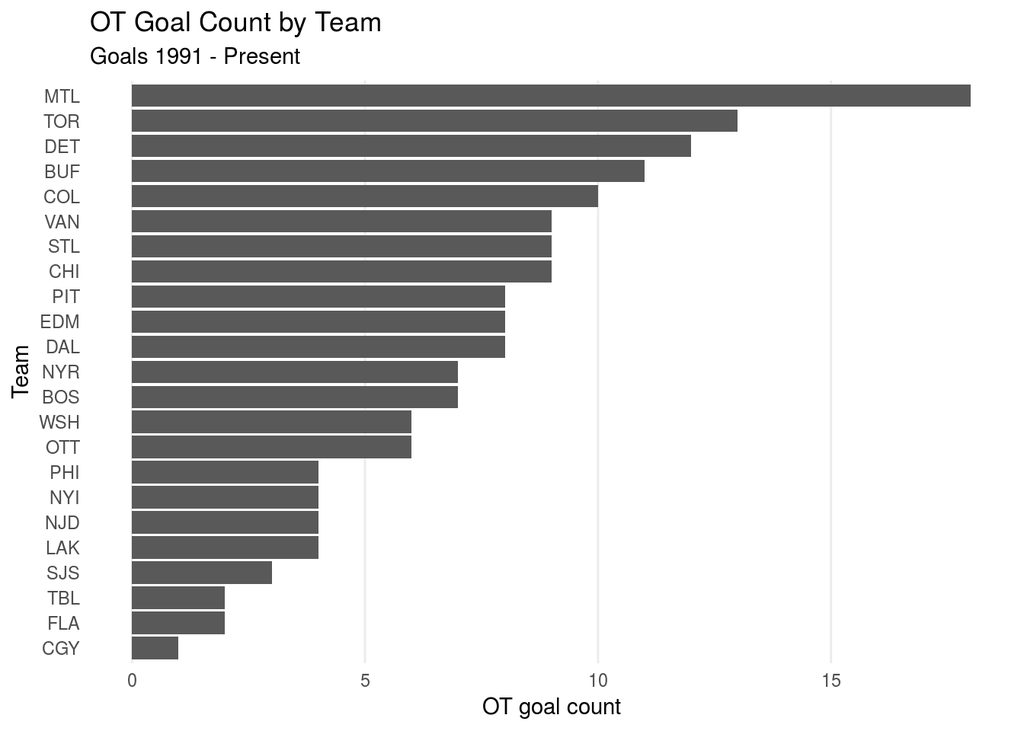

```r
plt2 <- ggplot(data = nhl, mapping = aes(x = reorder(TeamID, OTg_post_1991), y = OTg_post_1991)) +
  geom_bar(stat = "Identity") +
  labs( x = "Team",
        y = "OT goal count",
        title = "OT Goal Count by Team",
        subtitle = "Goals 1991 - Present") +
  theme_minimal()+
  theme(panel.grid.minor.x = element_blank(),
        panel.grid.major.y = element_blank(),
        panel.grid.minor.y = element_blank()) +
  coord_flip()

plt2
```

## Calculating goals per game average

- instead of looking into certain dates I decided to calculate the average number of goals per game, this would better account for teams who have scored more playoff OT goals due to more playoff appearances

```r
nhl_data3 <- cbind(nhl_data1, nhl_data1$W+nhl_data1$L)
names(nhl_data3)[7] = 'Total games'

nhl_data4 <- cbind(nhl_data3, nhl_data3$freq/nhl_data3$`Total games`)
names(nhl_data4)[8] = "Gpg"

nhl_data5 <- nhl_data4 %>%
  mutate_if(is.numeric, round, digits = 2)

head(nhl_data5)
```

```
##   TeamID                Team  W  L Pct. freq Total games  Gpg
## 1    ANA       Anaheim Ducks 16 13 0.55    0          29 0.00
## 2    ARI     Arizona Coyotes  4 19 0.17    0          23 0.00
## 3    BOS       Boston Bruins 60 65 0.48   38         125 0.30
## 4    BUF      Buffalo Sabres 21 29 0.42   21          50 0.42
## 5    CGY      Calgary Flames 16 28 0.36   11          44 0.25
## 6    CGS Carolina Hurricanes 12 12 0.50    0          24 0.00
```

## Putting it together

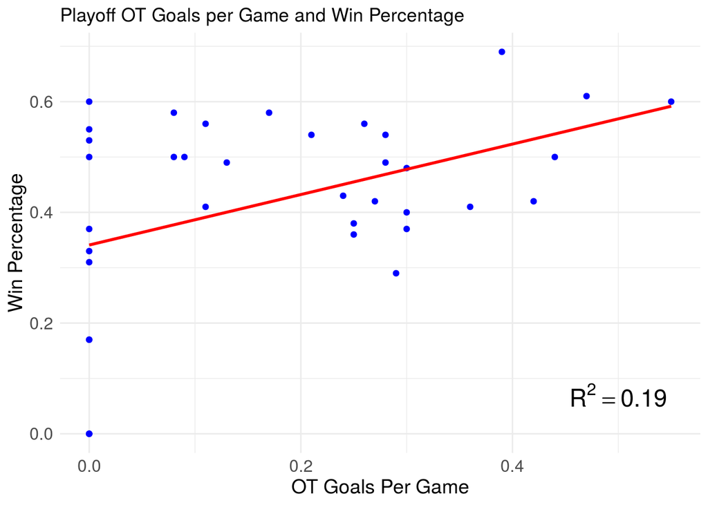

```r
mod2 <- lm(Gpg ~ Pct., data = nhl_data5)
r2_ <- broom::glance(mod2) %>% pull(r.squared) %>%
  round(., 2)

nhl_theme <- theme_minimal() +
  theme(axis.title = element_text(size = 14),
        axis.text = element_text(size = 12),
        strip.text = element_text(size = 12),
        axis.ticks = element_blank())

plt4 <- ggplot(nhl_data5, aes(x = Gpg, y = Pct.)) +
  geom_point(color = "blue") +
  geom_smooth(method = lm, se = FALSE, color = "red")  +
  annotate('text',
           x = 0.5, y = 0.07,
           label=glue::glue("R^2 == {r}", r=r2_),
           size=6,
           parse=T) +
      labs(x = "OT Goals Per Game",
      y = "Win Percentage",
      title = "Playoff OT Goals per Game and Win Percentage") +
  nhl_theme

plt4
```

## Making it interactive

- I also wanted to compare the functionality of using ggplotly and plotly to plot the same data

```r
library(plotly)
ggplotly(plt4)
```

[interactive chart not shown]

```r
fit <- lm(Pct. ~ Gpg , data = nhl_data5)
plt5 <- plot_ly(data = nhl_data5, x = nhl_data5$Gpg, y = nhl_data5$Pct., type = "scatter",
        mode = "markers", text = nhl_data5$TeamID) %>%
  add_lines(x = ~Gpg, y = fitted(fit)) %>%
  layout(title = "OT Goals per Game vs Win Percentage", showlegend = F,
         xaxis = list(title = "Goals per Game", showgrid = F),
         yaxis = list(title = "Win %", showgrid = F))
 plt5
```

[interactive chart not shown]